# gotit_data_test

## **Think It Data Intern Test**

### **Candidate: Trần Trịnh Mai Vy**

### **Requirements**

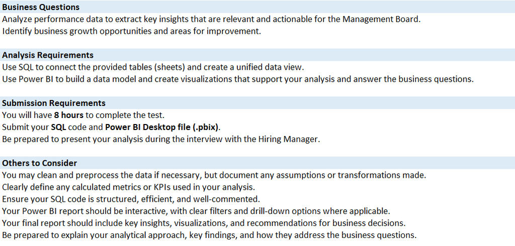

### **Connnect & create a unified data by MySQL**

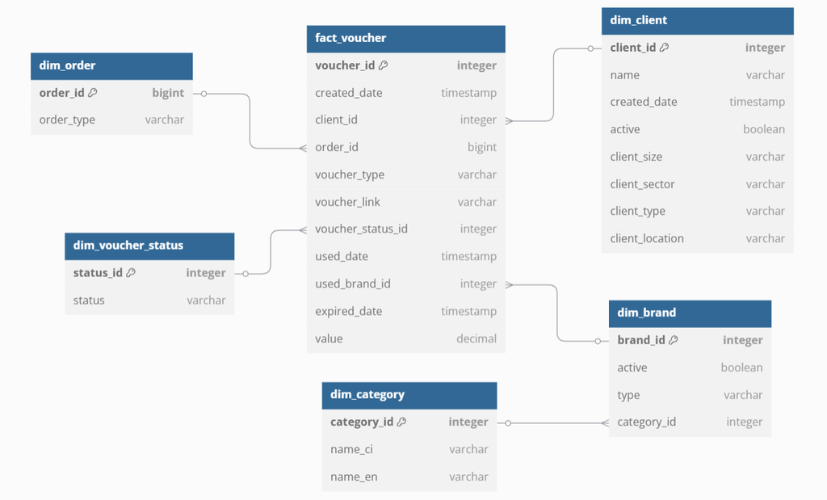

```python
# Kết nối với database
import pandas as pd
from sqlalchemy import create_engine, text
```

```python
# Thông tin kết nối MySQL
username = "root"
password = ""
host = "127.0.0.1"
database = "vouchers_management"

# Đường dẫn đến file Excel
datafile = "data.xlsx"

# Tạo engine kết nối
engine = create_engine(f"mysql+pymysql://{username}:{password}@{host}/{database}")
```

```python
# Đọc tất cả sheet trong file Excel
xls = pd.ExcelFile(datafile)

# Duyệt qua từng sheet và import vào MySQL
for sheet_name in xls.sheet_names:
    df = xls.parse(sheet_name)  # Đọc dữ liệu từ sheet
    df.to_sql(sheet_name, con=engine, if_exists='replace', index=False)  # Import vào MySQL
    print(f"Đã nhập dữ liệu vào bảng {sheet_name}")
```

```
Đã nhập dữ liệu vào bảng fact_voucher
Đã nhập dữ liệu vào bảng dim_order
Đã nhập dữ liệu vào bảng dim_client
Đã nhập dữ liệu vào bảng dim_brand
Đã nhập dữ liệu vào bảng dim_category
Đã nhập dữ liệu vào bảng dim_voucher_status
```

```python
# Danh sách các truy vấn cần thực hiện
queries = [
    # Thêm khóa chính (PRIMARY KEY) cho từng bảng
    "ALTER TABLE fact_voucher ADD PRIMARY KEY (voucher_id);",
    "ALTER TABLE dim_order ADD PRIMARY KEY (order_id);",
    "ALTER TABLE dim_client ADD PRIMARY KEY (client_id);",
    "ALTER TABLE dim_brand ADD PRIMARY KEY (brand_id);",
    "ALTER TABLE dim_category ADD PRIMARY KEY (category_id);",
    "ALTER TABLE dim_voucher_status ADD PRIMARY KEY (status_id);",

    # Thêm khóa ngoại (FOREIGN KEY) vào bảng fact_voucher
    "ALTER TABLE fact_voucher ADD CONSTRAINT fk_fact_voucher_client FOREIGN KEY (client_id) REFERENCES dim_client(client_id);",
    "ALTER TABLE fact_voucher ADD CONSTRAINT fk_fact_voucher_order FOREIGN KEY (order_id) REFERENCES dim_order(order_id);",
    "ALTER TABLE fact_voucher ADD CONSTRAINT fk_fact_voucher_status FOREIGN KEY (voucher_status_id) REFERENCES dim_voucher_status(status_id);",
    "ALTER TABLE fact_voucher ADD CONSTRAINT fk_fact_voucher_brand FOREIGN KEY (used_brand_id) REFERENCES dim_brand(brand_id);",

    # Thêm khóa ngoại cho bảng dim_brand
    "ALTER TABLE dim_brand ADD CONSTRAINT fk_dim_brand_category FOREIGN KEY (category_id) REFERENCES dim_category(category_id);",

    # Tạo View để kết hợp dữ liệu các bảng
    """
    CREATE VIEW brand_category_info AS
    SELECT
        b.brand_id,
        b.active,
        b.type,
        b.category_id,
        c.name_ci AS category_name_ci,
        c.name_en AS category_name_en
    FROM dim_brand b
    JOIN dim_category c ON b.category_id = c.category_id;
    """,
    """
    CREATE VIEW unified_data AS
    SELECT
        f.voucher_id,
        f.created_date,
        f.client_id,
        c.name AS client_name,
        c.created_date AS client_created_date,
        c.active AS client_active,
        c.client_size,
        c.client_sector,
        c.client_type,
        c.client_location,
        f.order_id,
        o.order_type,
        f.voucher_type,
        f.voucher_link,
        f.voucher_status_id,
        s.status AS voucher_status,
        f.used_date,
        f.used_brand_id,
        bc.active AS brand_active,
        bc.type AS brand_type,
        bc.category_id,
        bc.category_name_ci,
        bc.category_name_en,
        f.expired_date,
        f.value
    FROM fact_voucher f
    JOIN dim_client c ON f.client_id = c.client_id
    JOIN dim_order o ON f.order_id = o.order_id
    JOIN dim_voucher_status s ON f.voucher_status_id = s.status_id
    LEFT JOIN brand_category_info bc ON f.used_brand_id = bc.brand_id;
    """
]

# Thực hiện từng truy vấn
with engine.connect() as connection:
    for query in queries:
        try:
            connection.execute(query)
        except Exception as e:
            print(f"Lỗi khi thực hiện truy vấn: {query}\n{e}\n")
```

```python
with engine.connect() as conn:
    result = conn.execute(text("SHOW TABLES;"))
    for row in result:
        print(row)
```

```
('brand_category_info',)
('dim_brand',)
('dim_category',)
('dim_client',)
('dim_order',)
('dim_voucher_status',)
('fact_voucher',)
('unified_data',)
```

```python
# Đọc dữ liệu từ bảng
query = "SELECT * FROM unified_data"
df = pd.read_sql(query, engine)

# Hiển thị dữ liệu
df.head(5)
```

[output not shown]

5 rows × 25 columns

```python
df.shape
```

```
(92069, 25)
```

```python
# Lưu DataFrame vào file CSV
df.to_csv("data.csv", index=False, encoding="utf-8-sig")
```

### **Dashboard with PowerBI**

Loại hình kinh doanh mua bán voucher như của Got It mang lại nhiều lợi ích cho cả doanh nghiệp và người tiêu dùng. Đối với doanh nghiệp, việc phát hành voucher giúp thúc đẩy doanh số bán hàng, quảng bá thương hiệu và thu hút khách hàng mới. Đối với người tiêu dùng, voucher mang lại sự linh hoạt trong mua sắm, tiết kiệm chi phí và cơ hội trải nghiệm đa dạng sản phẩm, dịch vụ từ nhiều thương hiệu khác nhau.

[figure not shown]

Dựa trên dữ liệu cung cấp về tình hình hoạt động kinh doanh voucher từ 01/2022 - đến thời điểm hiện tại với các voucher được cung cấp đến hết năm 2024. Trong khoảng thời gian này, doanh doanh thu hút khoảng hơn 92 nghìn order ứng với 92K loại voucher tổng giá trị voucher phát hành khoảng gần 14 tỷ VND, bao gồm:

- Các voucher đã được sử dụng chiếm phần lớn nhất, tiếp theo là các voucher đã quá hạn sử dụng và một số voucher bị cancelled, inactive hay not counted chiếm khoảng 8K (9%) tổng số lượng order.
- Các order được tạo thủ cong bởi ADMIN chiếm phần lớn, tiếp theo là API
- Qua các năm hoạt động, dấu hiệu rất tích cực là số lượng order voucher từ các đoanh nghiệp client tăng lên, đặc biệt là thời điểm 2022-2023 tốc dộ tăng trưởng 100%, tiếp tục duy trì tăng trưởng nhẹ 12.5% năm 2024 sau đó và hiện tại vẫn tiếp tục họt động.
- Các voucher bán được hầu hết là bán cho client B2B với phần lớn là các e-voucher loại Digital voucher 88% so với Paper voucher, số lượng voucher bán ra ở dạng 'o' quy đổi thành tiền nhiều hơn loại 'p' loại voucher quy đổi và sau cùng là loại 'm' dùng trên nhiều thương hiệu trong cugf một voucher.
- Trong thời gian vừa qua, công ty đã thu hút các khách doanh nghiệp trên 12 lĩnh vực với nhóm doanh nghiệp ngân hàng, bảo hiểm và FMCG là các khách hàng quan trọng có số lượng order nhiều nhất.
- Thị trường miền Nam có sức mua cao nhất, cần tập trung phát triển hơn.
- Công ty cũng hợp tác với các thượng hiệu ứngứng với 9 phân loại kinh doanh các san phẩm dịch vụ trên hị trường, chủ yếu là các thương hiệu offline như nhà hàng, coffee & cake, supermarket và shopping tiếp đó các thượng hiệu online như tiện ích và truyền thông.=> Voucher ẩm thực và dịch vụ thiết yếu được sử dụng nhiều nhất.

#### Cơ hội tăng trưởng:

- Đẩy mạnh các loại voucher linh hoạt (loại "o"), vì đây là loại được ưa chuộng nhất.Khách hàng ưa chuộng voucher có thể quy đổi tiền mặt, cho thấy họ thích sự linh hoạt trong việc mua sắm thay vì bị giới hạn ở một sản phẩm cụ thể. Voucher loại "m" ít phổ biến hơn dự kiến. Doanh nghiệp có thể đẩy mạnh loại này bằng cách mở rộng danh sách thương hiệu chấp nhận. Có thể tối ưu hóa voucher loại "p" bằng cách đơn giản hóa điều kiện sử dụng, để thu hút thêm người dùng.
- Tăng cường thị phần tại miền Bắc & Trung, nơi có nhu cầu thấp hơn.
- Khai thác khách hàng cá nhân (C2C) để mở rộng đối tượng người dùng.
- Đẩy mạnh voucher trong ngành công nghệ, tài chính và nghiên cứu thị trường, vì đây là nhóm khách hàng tiềm năng.

#### Lĩnh vực cần cải thiện:

[figure not shown]

Đi sâu vào phân tích về nhóm khách hàng client, dựa vào data cho đên thời điểm cuối năm 2024, các order được đặt từ 35 khoách hàng doanh nghiệp (trong có có 2 doanh nghiệp đã ngưng hoạt động trên hệ thống):

```python
# Câu truy vấn SQL
query = """
SELECT
    client_id,
    client_name,
    client_size,
    client_sector,
    client_type,
    client_location,
    AVG(value) AS avg_value,
    COUNT(DISTINCT order_id) AS order_count
FROM
    unified_data
GROUP BY
    client_id,
    client_name,
    client_size,
    client_sector,
    client_type,
    client_location
ORDER BY
    order_count DESC
LIMIT 5;
"""

# Thực hiện truy vấn và đọc dữ liệu vào DataFrame
df = pd.read_sql(query, engine)

# Hiển thị kết quả
df
```

|  | client_id | client_name | client_size | client_sector | client_type | client_location | avg_value | order_count |
| --- | --- | --- | --- | --- | --- | --- | --- | --- |
| 0 | 2 | Công Ty TNHH Mì tôm Hảo | Large | FMCG | Client B2B | South | 141387.4133 | 16001 |
| 1 | 86 | Công ty Nghiên cứu Infos | Small | Market Research | Client B2B | South | 158485.7877 | 11293 |
| 2 | 3 | Bảo hiểm FHM | Large | Insurance | Client B2B | South | 193079.1846 | 10204 |
| 3 | 10 | Ngân Hàng Đại Việt | Med | Bank | Client B2B | Central | 135686.4901 | 9097 |
| 4 | 90 | Công Ty TNHH EcomVN | Small | IT(Information Technology) | Client B2B | South | 119251.5512 | 7736 |

```python
# Câu truy vấn SQL
query = """
SELECT
    bc.name_en brand_category_name,
    ROUND(AVG(f.value), 2) AS avg_value,
    COUNT(DISTINCT f.order_id) order_count
FROM
    fact_voucher f
JOIN
    dim_brand b ON f.used_brand_id = b.brand_id
JOIN
    dim_category bc ON b.category_id = bc.category_id
GROUP BY
    bc.name_en
ORDER BY
    avg_value DESC
LIMIT 5;
"""

# Thực hiện truy vấn và đọc dữ liệu vào DataFrame
df = pd.read_sql(query, engine)

# Hiển thị kết quả
df
```

|  | brand_category_name | avg_value | order_count |
| --- | --- | --- | --- |
| 0 | Utilities | 287349.71 | 16734 |
| 1 | Health Care | 154000.00 | 10 |
| 2 | Flower, Fruit & Fresh Food | 126356.28 | 247 |
| 3 | Supermarkets & Shopping | 87868.49 | 3148 |
| 4 | Entertainment | 85992.37 | 9180 |

[figure not shown]

Xét biến động xu hướng cho hoạt động kinh doanh voucher trong khoảng thời 2022-2024 đầu 2025:

- Xu hướng đặt hàng voucher của các doanh nghiệp khách hàng nhiều vào giai đoạn cuối năm và tháng 1 đầu năm (giai đoạn mua sắm chuẩn bị trước Tết, BlackFriday, dịp lêx Noel, ...) và giảm vào tháng 2 giai đoạn Tết và sau Tết sau đó các tăng dần đến cuối năm.
- Xu hướng sử dụng voucher của doanh nghiệp áp dụng quanh năm và cuối nắm số voucher đượcược doanh nghiệp sử dụng tăng lên, đối với năm 2022 việc sử dụng tăng dần phản ánh mức sử dụng voucher đang được quan tâm và áp dụng ở các doanh nghiệp.
- Số lượng voucher được tạo thêm ở 2023 và 2024 ít hơn 2022 thể hiện khách hàng ưa chuộng sử dụng các sản phẩm voucher cũ, công ty tạo được lòng tin quay lại của khách hàng. Xét xu hướng sử dụng nhóm thương hiệu của khách hàng: Nhận thấy xu hướng chung là đều sử dụng voucher ở các nhóm sản phẩm tiện ích, F&B phần lớn, tiếp đến là truyền thông và Supermarket, shopping.

### **Cơ hội tăng trưởng & Cải thiện**

**Nhận xét chung về xu hướng**

**Đề xuất cải thiện và cơ hội phát triển**

- Số lượng voucher mới giảm nhẹ ở 2023-2024 thể hiện khách hàng ưa chuộng sử dụng lại các sản phẩm voucher cũ, công ty tạo được lòng tin để khách hàng quay lại. => Tuy nhiên, cần update cung cấp đa dạng loại voucher mới hơn phù hợp với thị hiếu thị trường đáp ứng nhu cầu đa dạng phong phú cho người dùng.
- Tập trung phát triển các sản phẩm chất lượng và linh hoạt:
  - Tìm kiếm đối tác uy tín, xây dựng voucher hấp dẫn (giá trị vừa phải, chiết khấu tốt), pát triển thêm voucher online: Tích hợp e-commerce, dịch vụ streaming, game online để theo kịp xu hướng tiêu dùng số.
  - Chú trọng mở rộng thương hiệu hợp tác ở đa dạng các danh mục (đặc biệt là Tiệc ích, F&B và các danh mục tiềm năng), mở rông về vị trí của các thương hiệu để mở rộng thị trường ra cả Bắc và Trung.
  - Chú tâm vào nhu cầu sử dụng voucher của người tiêu dùng để tạo ra các sản phẩm phù hợp với các doanh nghiệp khách hàng.
- Chăm sóc khách hàng lâu năm và đẩy mạnh các chiến lược thu hút các kjachs hàng mới và tiềm năng khác.
- Tận dụng các dịp lễ dịp lễ nhỏ (Valentine, 8/3, 30/4 - 1/5) hay dịp mua sắm cuối/ đầu/ giữa tháng để chọn hạn dùng voucher phù hơpj để duy trì sức mua.